# Session 2

## Vector

### How to modify a vector

6. Converting Vector Type
1. Numeric to Character

```r
x<-1:5; as.character(x)   # Note the ""
```

```
[1] "1" "2" "3" "4" "5"
```

2. Character to Numeric

```r
# NA will be introduced if the string is not a number
x<-c("1", "2", "not a number", "Inf"); as.numeric(x) # Expect warnings
```

```
Warning: NAs introduced by coercion
```

```
[1]   1   2  NA Inf
```

## Vector

### How to modify a vector

6. Converting Vector Type
3. Character to Factor –

   [`factor()`, `as.factor`, `ordered()`, `as.ordered()`](https://www.rdocumentation.org/packages/base/versions/3.6.2/topics/factor)

```r
x<-rep(c("Stuzin", "Hough", "Bryan"), c(2,1,3))
y<-factor(x)    # ordered(x) if ordinal
y               # Check the levels
```

```
[1] Stuzin Stuzin Hough  Bryan  Bryan  Bryan
Levels: Bryan Hough Stuzin
```

```r
z<-factor(x, levels=c("Stuzin", "Bryan", "Hough"))
z               # May be important to set your "base"
```

```
[1] Stuzin Stuzin Hough  Bryan  Bryan  Bryan
Levels: Stuzin Bryan Hough
```

## Vector

### How to modify a vector

6. Converting Vector Type
4. Factor to Character

```r
as.character(y); as.character(z)
```

[output not shown]

## Vector

### How to modify a vector

6. Converting Vector type
5. Numeric to Factor

```r
x<-c(0,1,1,0,1,1,0);   y<-factor(x, levels=c(1,0));   y
```

```
[1] 0 1 1 0 1 1 0
Levels: 1 0
```

6. Factor to Numeric – Caution!

```r
as.numeric(y) # What happened? Why not 0, 1, 1, 0, 1, 1, 0?
```

```
[1] 2 1 1 2 1 1 2
```

```r
as.numeric(as.character(y)) # Sol: Convert to character type first!
```

## Vector

### How to modify a vector

6. Converting Vector type
6. Character to Date

```r
as.Date("2021-09-23")
as.Date("09/23/2021", format="%m/%d/%Y")
ISOdate(year="2021", month="09", day="23") # Also has other arguments
lubridate::ymd("2021-09-23")
```

**NOTE**: Please check the [`lubridate`](https://cran.r-project.org/web/packages/lubridate/lubridate.pdf) package

## Vector

### How to modify a vector

7. Vector Operations –

   Understanding vectorized operations in R

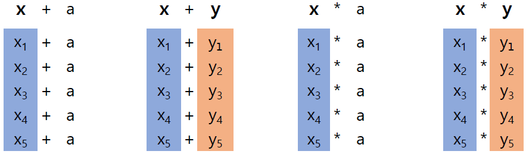

**x** and **y** are vectors and `a` is a numeric value

```r
x<-1:5; x+2
```

```
[1] 3 4 5 6 7
```

**NOTE**: Vectorized operations are **NOT** limited to the four basic asthmatics

**NOTE**: Vectorization – operating on all the elements of a vector at once – is a key to efficient coding in R

## Vector

### How to modify a vector

7. Vector Operations –

   Understanding vectorized operations in R

```r
x<-1:5; y<-6:10
```

```r
y+x
-3*x
y/x
x^y
sqrt(x)
```

## Vector

### How to modify a vector

7. Vector Operations –

   Understanding vectorized operations in R

```r
UF_bldg
```

```
       STZ        HGS        BRY       HVNR        GER
  "Stuzin"    "Hough"    "Bryan" "Heavener"   "Gerson"
```

```r
paste0(UF_bldg, " Hall")
```

```
[1] "Stuzin Hall"   "Hough Hall"    "Bryan Hall"    "Heavener Hall"
[5] "Gerson Hall"
```

Check [`paste() and paste0()`](https://www.google.com/search?client=firefox-b-1-d&q=r+paste0) functions

**NOTE**:We will cover more about strings in Session 6

## Vector

### How to summarize a vector

1. Any summary statistics –

   `mean()`, `sd()`, `sum()`, `min()`, `max()`, `range()`, etc.

```r
x<-1:10;
mean(x); sd(x); sum(x);
```

[output not shown]

```r
mean(c(1,2,NA,3))          # What if you have NAs?
```

```
[1] NA
```

```r
mean(c(1,2,NA,3), na.rm=T) # Use  na.rm=" argument
```

```
[1] 2
```

## Vector

### How to summarize a vector

2. [`summary()`](https://www.rdocumentation.org/packages/base/versions/3.6.2/topics/summary) – when class is “numeric”

```r
summary(x)  # Generates 5-number-summary when class is numeric
```

```
   Min. 1st Qu.  Median    Mean 3rd Qu.    Max.
   1.00    3.25    5.50    5.50    7.75   10.00
```

**NOTE**: `Summary()` function can do more than just summarizing numeric vectors

## Vector

### How to summarize a vector

3. Count obs. with [`table()`](https://www.rdocumentation.org/packages/base/versions/3.6.2/topics/table) function

```r
x<-rep(c("A", "B", "C", "F"), c(3,5,2,1))
table(x)
```

[output not shown]

```r
prop.table(table(x))   # returns proportion instead of counts
```

```r
x<-rep(c(1.2,-3,2.13,pi), c(3,5,2,1))
table(x)               # you can use table w/ numeric-type but...
```

```
     -3     1.2    2.13 3.14159
      5       3       2       1
```

## Matrix

### How to create a Matrix

1. Create an empty matrix of NAs

```r
matrix(nrow = 2, ncol = 3)
```

```
     [,1] [,2] [,3]
[1,]   NA   NA   NA
[2,]   NA   NA   NA
```

```r
matrix(nrow = 2, ncol = 3,           # Can assign row and col names
       dimnames = list(paste0("r", 1:2), paste0("c", 1:3)))
```

```
   c1 c2 c3
r1 NA NA NA
r2 NA NA NA
```

Check [`matrix()`](https://www.rdocumentation.org/packages/base/versions/3.6.2/topics/matrix) function

## Matrix

### How to create a Matrix

2. Create a matrix from a vector

```r
matrix(1:12, nrow=3)           # column-wise fill
```

```
     [,1] [,2] [,3] [,4]
[1,]    1    4    7   10
[2,]    2    5    8   11
[3,]    3    6    9   12
```

```r
matrix(1:12, nrow=3, byrow=T)  # row-wise fill
```

```
     [,1] [,2] [,3] [,4]
[1,]    1    2    3    4
[2,]    5    6    7    8
[3,]    9   10   11   12
```

## Matrix

### How to create a Matrix

3. Create a matrix by binding vectors
1. `rbind()` – row bind

```r
rbind(c(1, 2), c(3, 4))
```

```
     [,1] [,2]
[1,]    1    2
[2,]    3    4
```

2. `cbind()` – column bind

```r
cbind(c(1, 2), c(3, 4))
```

```
     [,1] [,2]
[1,]    1    3
[2,]    2    4
```

## Matrix

### How to create a Matrix

3. Create a matrix by binding vectors – can also bind matrices

```r
mdat<-matrix(letters[1:4], nrow=2) # a matrix can be of character-type
rbind(mdat, paste0("new_r", 1:2))  # row-bind a vector to a matrix
```

```
     [,1]     [,2]
[1,] "a"      "c"
[2,] "b"      "d"
[3,] "new_r1" "new_r2"
```

```r
mdat<-matrix(letters[1:4], nrow=2)
Mdat<-matrix(LETTERS[1:4], nrow=2)
cbind(mdat, Mdat)                  # column-bind two matrices
```

## Matrix

### How to create a Matrix

3. Create a matrix by binding vectors
- Binding vectors with different length

```r
rbind(1:5, 6:7) # Warning... 6 7 repeats; cbind also behaves similarly
```

```
Warning in rbind(1:5, 6:7): number of columns of result is not a multiple of
vector length (arg 2)
```

```
     [,1] [,2] [,3] [,4] [,5]
[1,]    1    2    3    4    5
[2,]    6    7    6    7    6
```

## Matrix

### How to create a Matrix

3. Create a matrix by binding vectors
- Binding vectors with different length – fill with NA

```r
x<-1:5; y<-6:7
max_length=max(length(x), length(y))
length(x)<-max_length; length(y)<-max_length  # x/y now same length
rbind(x, y)
```

```
  [,1] [,2] [,3] [,4] [,5]
x    1    2    3    4    5
y    6    7   NA   NA   NA
```

**NOTE**: There are functions/pkgs that do the same job – e.g. [`plyr::rbind.fill`](https://cran.r-project.org/web/packages/plyr/plyr.pdf)  
Btw, `plyr` and `dplyr` pkgs are written by the same author and some functions share the same name.  
⇒ Use `::` to distinguish the two packages

## Matrix

### How to create a Matrix

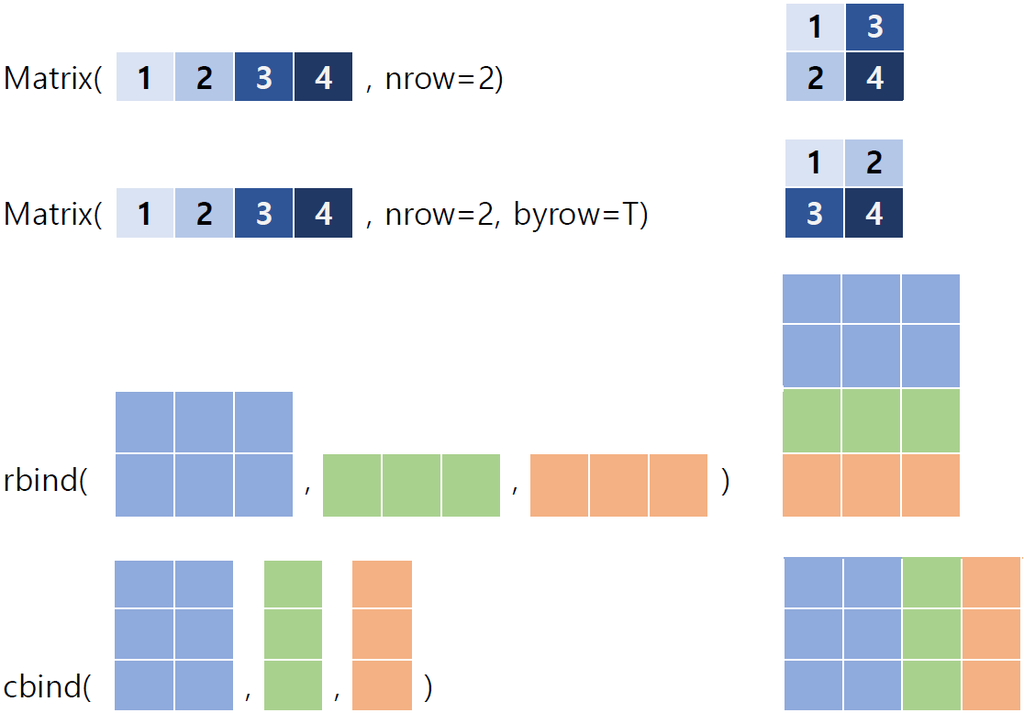

Make sure the dimensions are correct!

## Matrix

### How to create a Matrix

4. Create a matrix merging two matrices – [`merge()`](https://www.rdocumentation.org/packages/base/versions/3.6.2/topics/merge) function

```r
# New Example!
mdat1<-matrix(1:4, nrow=2, dimnames = list(c("r1", "r2"), c("c1", "c2")))
mdat2<-matrix(c(3, 5:7), nrow=2, dimnames = list(c("r1", "r3"), c("c2", "c3")))
# mdat2<-matrix(5:8, nrow=2, dimnames = list(c("r1", "r3"), c("c2", "c3")))
```

```r
# New Example!
merge(mdat1, mdat2, all=F)
merge(mdat1, mdat2, by="c2")  # merge by column name
merge(mdat1, mdat2, all=TRUE)
# merge(mdat1, mdat2, all=TRUE)[order(names(merge(mdat1, mdat2, all=TRUE)))]
```

## Matrix

### Examine a Matrix

```r
Mdat<-matrix(LETTERS[1:6], nrow=3,
             dimnames = list(paste0("r", 1:3), paste0("c", 1:2)))
```

1. `str()` – Check overall structure and type

```r
str(Mdat)
```

2. Check matrix dimension

```r
dim(Mdat); nrow(Mdat); ncol(Mdat); length(Mdat) # 3 2; 3; 2; 6 respectively
```

3. Check names

```r
row.names(Mdat); colnames(Mdat) # "r1" "r2" "r3"; "c1" "c2" receptively
```

Also check the `class`, `typeof`, `attributes`

## Matrix

### How to subset a Matrix

Use square brackets [] to subset a matrix

```r
# Basic Syntax
a_matrix[row_condition, col_condition] # row/col cond. separated by a comma
```

Recall… condition types

1. Logical vector
2. Index (integer)
3. Names

Similar to vector but there are two conditions – row and column

## Matrix

### How to subset a Matrix

```r
mdat<-matrix(1:12, nrow = 3,       # Can assign row and col names
       dimnames = list(paste0("r", 1:3), paste0("c", 1:4)))
```

1. Index

```r
mdat[2, 1, drop=F] # row 2 and col 1; drop=F to keep the matrix structure
mdat[, 1:2]        # all rows; col 1 and 2 (blank means everything)
mdat[c(-2,-4), - c(1, 3)] # rows except 2 and 4; cols except 1 and 3
```

2. Names

```r
mdat[c("r1", "r3"), c("c2", "c4")]  # Must be a named matrix
```

3. Logical

```r
mdat[c(T,F,T), c(F, T, T, F)] # any Boolean output (relational/logical op.)
```

## Matrix

### How to modify a Matrix

1. Replace `NA`s with value(s)

```r
mdat<-matrix(c(1,1, NA, 3, 3, 2, 4, NA, 4, 3, 3, 2), nrow=3)
```

```
     [,1] [,2] [,3] [,4]
[1,]    1    3    4    3
[2,]    1    3   NA    3
[3,]   NA    2    4    2
```

```r
mdat[is.na(mdat)]<-999  # What's the differece btw mdat[]<-0 and mdat<-0?
```

```
     [,1] [,2] [,3] [,4]
[1,]    1    3    4    3
[2,]    1    3  999    3
[3,]  999    2    4    2
```

## Matrix

### How to modify a Matrix

2. Complete Observations

```r
# Note: A single row or a column of a matrix is a vector
mdat[complete.cases(mdat), ]         # a vector;  class: "numeric"
```

```
[1] 1 3 4 3
```

```r
mdat[complete.cases(mdat), , drop=F] # a matrix;  class: "matrix" "array"
```

```
     [,1] [,2] [,3] [,4]
[1,]    1    3    4    3
```

## Matrix

### How to modify a Matrix

3. Unique observations

```r
mdat[is.na(mdat)]<-c(NA,4) # in the prev. slide replaced with 999. But...
unique(mdat)               # row-wise operation (remove duplicated rows)
mdat[!duplicated(mdat), ]  # Can also use the 'duplicated' function
```

```
     [,1] [,2] [,3] [,4]
[1,]    1    3    4    3
[2,]   NA    2    4    2
```

```r
t(unique(t(mdat)))        # transpose to remove duplicated columns
```

```
     [,1] [,2] [,3]
[1,]    1    3    4
[2,]    1    3    4
[3,]   NA    2    4
```

## Matrix

### How to modify a Matrix

4. Row and column names of a matrix
- Get/Set names – [`row.names()`](https://www.rdocumentation.org/packages/base/versions/3.6.2/topics/row.names) and [`colnames()`](https://www.rdocumentation.org/packages/base/versions/3.6.2/topics/row%2Bcolnames) functions

```r
mdat                                      # dim(mdat);  3 4
row.names(mdat)                           # NULL; no row name assigned
colnames(mdat)                            # NULL; no column name either
row.names(mdat)<-c("r1", "r2", "r3")      # Assign row names
colnames(mdat)<-c("c1", "c2", "c3", "c4") # Assign column names
```

cf. [`dimnames()`](https://www.rdocumentation.org/packages/base/versions/3.6.2/topics/dimnames)

## Matrix

### How to modify a Matrix

4. Get/Set Row and Column Names of a matrix
- Name vectors while using them as building blocks

```r
rbind(r1=1:3, r2=4:6, r3=7:9)     # Note: difference btw = vs. <-
```

```
   [,1] [,2] [,3]
r1    1    2    3
r2    4    5    6
r3    7    8    9
```

```r
cbind(c1=1:3, c2=4:6, c3=7:9)
```

```
     c1 c2 c3
[1,]  1  4  7
[2,]  2  5  8
[3,]  3  6  9
```

## Matrix

### Useful matrix-related functions

1. [`diag()`](https://www.rdocumentation.org/packages/base/versions/3.6.2/topics/diag) – To create identity matrix

2. ```r
   diag(3)                   # 3x3 identity matrix
   diag(matrix(1:9, nrow=3)) # Diagonal elements of a matrix
   upper.tri(); lower.tri()
   t()
   ```

## Array

## List

### How to create a list

1. Creating an empty list

```r
vector("list", length=3) # Empty list of length 3
# Note: list is also called a generic vector
```

2. Creating a list with [`list()`](https://www.rdocumentation.org/packages/base/versions/3.6.2/topics/list) function

```r
list(vect=c(1,2,3), another_list=list(a=c("apple", "avocado"), b=1:5), mat=matrix(c(1,2,3,4), ncol=2), df=data.frame(v1=1:3, v2=c("a", "b", "c")))
```

## Agg

```r
# aggregate(mdat, by=list(c1, c2), mean)
# 2.0aggregate(c1~., data=mdat, mean)
# aggregate(weight ~ feed, data = chickwts, mean)
# aggregate(. ~ Species, data = iris, mean)
# aggregate(state.x77, list(Region = state.region), mean)

testDF <- data.frame(v1 = c(1,3,5,7,8,3,5,NA,4,5,7,9),
                     v2 = c(11,33,55,77,88,33,55,NA,44,55,77,99) )
by1 <- c("red", "blue", 1, 2, NA, "big", 1, 2, "red", 1, NA, 12)
by2 <- c("wet", "dry", 99, 95, NA, "damp", 95, 99, "red", 99, NA, NA)
aggregate(x = testDF, by = list(by1, by2), FUN = "mean")

ag <- aggregate(len ~ ., data = ToothGrowth, mean)
xtabs(len ~ ., data = ag)
```

## Matrix

### How to modify a Matrix

4. vector/matrix Asthmatics

```r
mdat<-matrix(1:4, nrow=2)

mdat+2          # Vectorization also works
mdat*2
mdat*c(-1,2)

c(1,2,3) * c(4,5,6)
c(1,2,3) %*% c(4,5,6)  # Inner product

mdat%*%c(-1,2)
c(-1,2) %*% mdat

# Estimated parameters of a OLS is:
# $$\hat{\beta}=(X^TX)^{-1}(X^Ty)$$

summary(lm(mpg~1+cyl+hp+wt, data=mtcars))

y=mtcars$mpg
# x=as.matrix(cbind(intecept=rep(1, nrow(mtcars)), mtcars[c("cyl", "hp", "wt")]))
mtcars$intercept=1
x<-as.matrix(mtcars[c("intercept", "cyl", "hp", "wt")])
beta_hat=solve(t(x)%*%x)%*%(t(x)%*%y)
```